# Mosaic Plots - Basic Interpretation

Deepak Yadav

4th Mar, 2016

A mosaic plot is a graphical display used to examine the relationship among two or more categorical variables. Here, we will analyze the `happy` dataset using a mosaic plot from the `productplots` package. We will take a look at the relationship between `sex` and `level of happiness`, taking the `level of happiness` as the first split and `sex` as the second split.

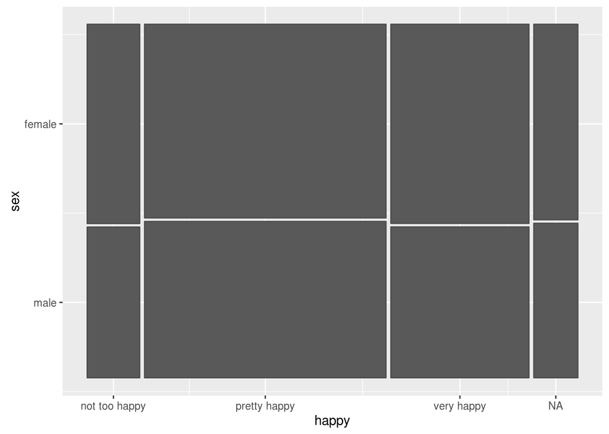

```r
library(productplots)
prodplot(happy, ~ sex + happy, mosaic())
```

`sex` is a factor with two categories - `male` and `female`. And `happy` is a factor with four categories - `not too happy`, `pretty happy`, `very happy` and `NA`. These four categories are seperated by vertical lines and width of each category shows the proportion of people in the respective categories. For each category of happy factor we have two parts which show proportion of males and females in that category.

The basic property of a mosaic plot resides in the fact that the higher the cell frequency in the contingency table, the greater the area of the corresponding rectangle. For example, in our dataset since the area of the `females` under the `pretty happy` category seems to be the largest, we can conclude that the number of females that fall under the `pretty happy` level of happiness is the greatest.

This type of plot is convenient if we want to examine the relationship between categorical variables (factors) without looking into numbers. In this example, we can also infer that the approximate proportion of `males` and `females` in each `level of happiness` is nearly the same. So in this case, the `level of happiness` seems to be independent of `sex`.